# RTS Final

6/1/2019

## Problem statement

Use time series techniques to learn and construct new music conforming to the style of Beethoven’s Moonlight Sonata.

**Disclaimer**: time series might not be the best tool for the problem because, although music looks like a continuous time series on a superficial level, it is discrete and not continuous, so something like HMM might be a better way to tackle it. But again, if you have a hammer, everything looks like a nail :)

## Moonlight Sonata as a time series (arpeggios)

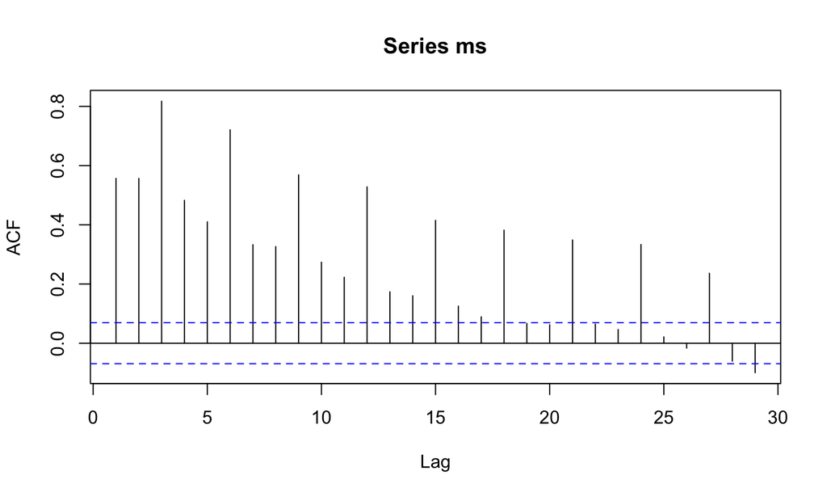

```
##
##  Augmented Dickey-Fuller Test
##
## data:  ms
## Dickey-Fuller = -3.4876, Lag order = 9, p-value = 0.0435
## alternative hypothesis: stationary
```

```
##
##  KPSS Test for Level Stationarity
##
## data:  ms
## KPSS Level = 0.32934, Truncation lag parameter = 6, p-value = 0.1
```

This is a stationary time series but does exhibit some patterns. There are repeating sequences of 3-note patterns and differencing by 3 improves the model. Again, since our goal is not predicting but identifying the music structure and trying to generate real music, the differencing helps.

## Trying to make moonlight sonata stationary

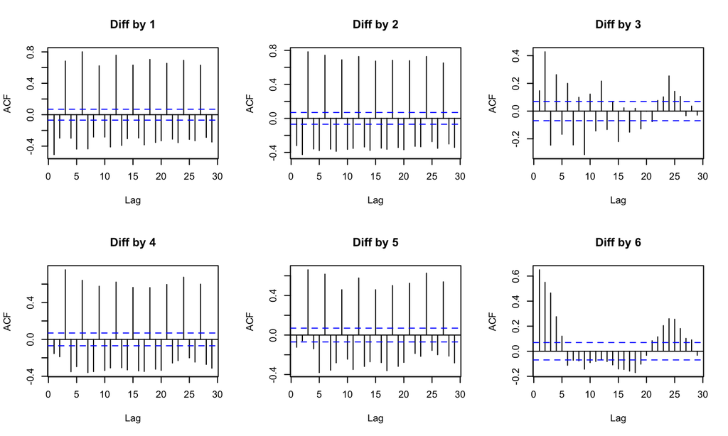

As we can see, the song exhibits a pattern that for lags of multiples of 3 the ACF start to show exponentially decreasing pattern, and at other lags it looks very unstationary with high correlations at each lag. Therefore, we will proceed to difference the time series by 3.

## Moonlight sonata lag by 3

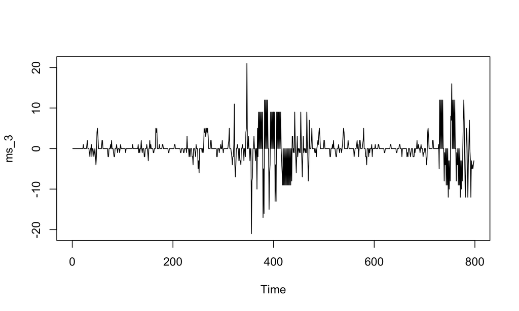

## Trying to fit an ARIMA model on this time series

```r
aarima_fit <- auto.arima(ms_3)
summary(aarima_fit)
```

```
## Series: ms_3
## ARIMA(1,0,4) with zero mean
##
## Coefficients:
##           ar1     ma1     ma2     ma3      ma4
##       -0.9562  1.3889  0.9542  0.1902  -0.1811
## s.e.   0.0148  0.0373  0.0572  0.0565   0.0365
##
## sigma^2 estimated as 7.438:  log likelihood=-1931.47
## AIC=3874.94   AICc=3875.04   BIC=3903.03
##
## Training set error measures:
##                       ME     RMSE     MAE MPE MAPE      MASE         ACF1
## Training set -0.04579418 2.718686 1.63699 NaN  Inf 0.6572701 -0.005812973
```

## Problems with this model

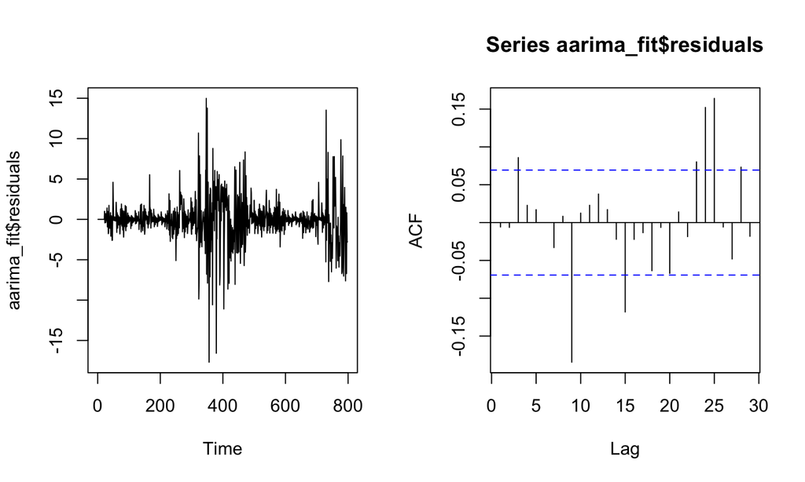

## Problems with this model

```r
Box.test(aarima_fit$residuals, type = "L", lag = 10)
```

```
##
##  Box-Ljung test
##
## data:  aarima_fit$residuals
## X-squared = 35.255, df = 10, p-value = 0.000113
```

The problem is that the residuals are not white noise. It shows both time-dependent change in variance as well as autocorrelation.

## Sophisticated Model 1: GARCHh

GARCH model is a method for dealing with heteroscedasticity in residuals, so we hope this will be more applicable to our data.

This GARCH model has a log likelihood of 1585.0695755, which is an improvement from `auto.arima`’s -1931.4676347.

## Even Garch model can’t bring residuals under control…

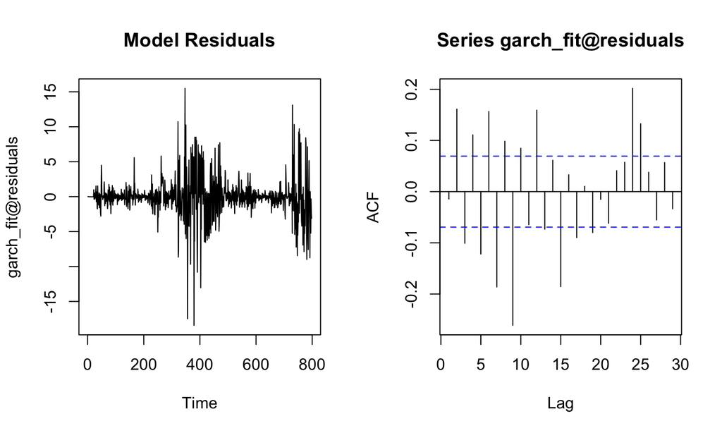

Even with garch the residuals are still showing varying variance and autocorrelation.

## Sophisticated Model 2: Vector regression

Given the song’s particular structure of repeating 3-note arpeggio patterns, it might be useful to reshape the data into a matrix of n*3 and use vector regression to tackle the problem.

```
##
## VAR Estimation Results:
## =========================
## Endogenous variables: y1, y2, y3
## Deterministic variables: const
## Sample size: 266
## Log Likelihood: -2268.578
## Roots of the characteristic polynomial:
## 0.8097 0.6959 0.1961
## Call:
## VAR(y = ms_3col, p = 1, type = "const")
##
##
## Estimation results for equation y1:
## ===================================
## y1 = y1.l1 + y2.l1 + y3.l1 + const
##
##       Estimate Std. Error t value Pr(>|t|)
## y1.l1 -0.20688    0.07111  -2.909 0.003934 **
## y2.l1 -0.16971    0.03079  -5.511 8.53e-08 ***
## y3.l1  0.16231    0.04616   3.517 0.000515 ***
## const 73.07653    4.03378  18.116  < 2e-16 ***
## ---
## Signif. codes:  0 '***' 0.001 '**' 0.01 '*' 0.05 '.' 0.1 ' ' 1
##
##
## Residual standard error: 3.815 on 262 degrees of freedom
## Multiple R-Squared: 0.1362,  Adjusted R-squared: 0.1263
## F-statistic: 13.77 on 3 and 262 DF,  p-value: 2.296e-08
##
##
## Estimation results for equation y2:
## ===================================
## y2 = y1.l1 + y2.l1 + y3.l1 + const
##
##       Estimate Std. Error t value Pr(>|t|)
## y1.l1 -0.59290    0.09750  -6.081 4.21e-09 ***
## y2.l1  0.66703    0.04222  15.797  < 2e-16 ***
## y3.l1  0.19306    0.06329   3.051  0.00252 **
## const 44.40299    5.53090   8.028 3.35e-14 ***
```

[output cut: 24 more lines]

```
## F-statistic: 72.67 on 3 and 262 DF,  p-value: < 2.2e-16
##
##
##
## Covariance matrix of residuals:
##        y1      y2      y3
## y1 14.555  3.9809 11.2862
## y2  3.981 27.3633 -0.2892
## y3 11.286 -0.2892 23.2309
##
## Correlation matrix of residuals:
##        y1       y2       y3
## y1 1.0000  0.19948  0.61378
## y2 0.1995  1.00000 -0.01147
## y3 0.6138 -0.01147  1.00000
```

## Vector regression is also problematic and fails to reduce residuals to white noise

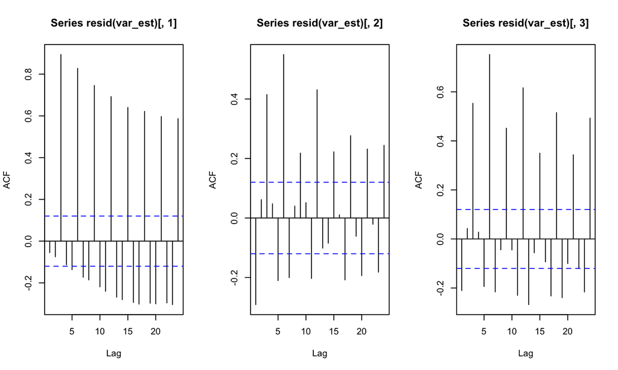

This method is roughly similar to an autoregressive method taking into account the structure of the data. As such it didn’t add much to what we have already tried in terms of bringing residuals under control.

## Better Model 1: Simple Markov Chain

This model takes each note as a discrete event and therefore can lead to better fit. We calculate the transition matrix for each note vs 3 notes into the future.

## Markov Chain predictions

To predict, we simply give it a 3 note sequence in vector form. Since our transition matrix has a particular form, we have to conform to it, and mark the corresponding note with a 1.

For example, a three note sequence corresponding to the start of the song (notes 56, 61, 64, a C# minor chord) can be written as:

```
##  [1] 0 0 0 0 0 0 0 0 0 0 1 0 0 0 0 0 0 0 0 0 0 0 0 0 0 0 0 0 0 0 0 0 0 0 0
## [36] 0 0
```

```
##  [1] 0 0 0 0 0 0 0 0 0 0 0 0 0 0 0 1 0 0 0 0 0 0 0 0 0 0 0 0 0 0 0 0 0 0 0
## [36] 0 0
```

```
##  [1] 0 0 0 0 0 0 0 0 0 0 0 0 0 0 0 0 0 0 1 0 0 0 0 0 0 0 0 0 0 0 0 0 0 0 0
## [36] 0 0
```

Where 1s correspond to the position of the note. Then we simply multiply each 1-hot vector with the transition matrix to get the probability for the future note (which we sample).

## Learning results

To make predictions, we use each model’s default `forecast` method to predict 48 notes down the line, or 4 measures into the future. We add some noise based on the model parameters. We will then round all predictions to its nearest whole number. Note, for time series models the predictions start with the last note.

We tried DirRec method as well, but the error would blow up substantially after just a few steps due to added noise to point estimates, so we abandoned the approach and treat any musicality as the result of noise.